```python
import numpy as np
from scipy.optimize import anderson
from scipy.optimize import fsolve
from scipy.linalg import solve
from scipy.integrate import simpson
import matplotlib.pyplot as plt
%matplotlib inline
```

# The Lieb-Liniger Gas

Original paper: https://doi.org/10.1063/1.1664947  
Also of interest is the following scipost review: https://scipost.org/SciPostPhysCore.7.3.047

We are in interested in the ground state behavior of bosons interacting with a $\delta$-function interaction at some finite temperature T $$ H \equiv - \lambda \sum_j {d^2 \over d x_j^2}+g\sum_{i\neq j} \delta \left(x_i-x_j\right) $$ for a system of $N$ bosons on a ring of length $L$ where $\lambda = \hbar^2 / 2m$.
For simplicity we will take $\hbar, k_B = 1$ and $\lambda = 1/2$.

Our approach is as follows:

1. We fix $\mu$
2. We solve $\epsilon(k)$ self-iteratively and plug that in to solve for $\rho_p(k)$
3. We evaluate $n$

We can solve them in python.

```python
def yang_yang_solver(c, mu, T, kmax=10.0, N=400, max_iter=2000, tol=1e-8, verbose=True):
    """
    Solve the Lieb-Liniger Yang-Yang integral equation for ε(k):
        ε(k) = k^2 - μ - (T/2π) ∫ dq [ 2c / (c^2 + (k-q)^2) ] * log(1 + exp(-ε(q)/T))

    Parameters
    ----------
    c : float
        Interaction strength (>0)
    mu : float
        Chemical potential
    T : float
        Temperature (in energy units)
    kmax : float
        Cutoff for integration in k-space
    N : int
        Number of discretization points in k ∈ [-kmax, kmax]
    max_iter : int
        Maximum iterations for fixed-point iteration
    tol : float
        Convergence tolerance for |ε_new - ε_old|
    verbose : bool
        Print convergence info

    Returns
    -------
    k : ndarray
        Discretized rapidity grid
    eps : ndarray
        Pseudoenergy ε(k)
    """

    # Discretization grid
    k = np.linspace(-kmax, kmax, N)
    dk = k[1] - k[0]

    # Kernel matrix K(k,q)
    dq = k[None, :] - k[:, None]   # (N,N)
    K = (c) / ((c)**2 + dq**2)

    # Initialize epsilon(k)
    eps = 0.5*k**2 - mu

    for it in range(max_iter):
        eps_old = eps.copy()

        # Compute log(1 + exp(-eps/T)) term
        logterm = np.log1p(np.exp(-eps / T))

        # Integral term
        integral = K @ logterm * dk

        eps = 0.5*k**2 - mu - T * integral / (np.pi)

        # Check convergence
        diff = np.max(np.abs(eps - eps_old))
        if verbose and it % 100 == 0:
            print(f"Iter {it:4d}: Δ = {diff:.3e}")
        if diff < tol:
            if verbose:
                print(f"Converged in {it} iterations, Δ = {diff:.3e}")
            break
    else:
        print("Warning: did not converge")

    return k, eps
def calculate_rho(c, eps, T, k, max_iter=2000, tol=1e-8, verbose=True):
    """
    Solve the Lieb-Liniger Yang-Yang integral equation for ε(k):
        2ρ(k)(1 + exp(ε(k)/T)) = 1 + ∫ dq [ 2g / (g^2 + (k-q)^2) ] * ρ(q)

    Parameters
    ----------
    c : float
        Interaction strength (>0)
    eps : array of eps(k)
        Chemical potential
    T : float
        Temperature (in energy units)
    k : array of values of k where eps(k) has been evaluated
        Cutoff for integration in k-space
    max_iter : int
        Maximum iterations for fixed-point iteration
    tol : float
        Convergence tolerance for |ε_new - ε_old|
    verbose : bool
        Print convergence info

    Returns
    -------
    k : ndarray
        Discretized rapidity grid
    rho : ndarray
        Particle density rho(k)
    """

    # Discretization grid
    dk = k[1] - k[0]
    # Kernel matrix K(k,q)
    dq = k[None, :] - k[:, None]   # (N,N)
    K = (2 * c) / ((c)**2 + dq**2)

    # Initialize epsilon(k)
    rho = np.ones(len(k))/(2*np.pi*(1 + np.exp(eps/T)))
    for it in range(max_iter):
        rho_old = rho.copy()
        #LHS term
        pref = 2*np.pi*(1 + np.exp(eps/T))
        # Integral term
        integral = K @ rho * dk

        rho = (1 + integral)/pref

        # Check convergence
        diff = np.max(np.abs(rho - rho_old))
        if verbose and it % 100 == 0:
            print(f"Iter {it:4d}: Δ = {diff:.3e}")
        if diff < tol:
            if verbose:
                print(f"Converged in {it} iterations, Δ = {diff:.3e}")
            break
    else:
        print("Warning: did not converge")

    return k, rho
#
def solve_TBA(c,mu,T,kmax,N):
    k, eps = yang_yang_solver(c, mu, T, kmax, N,verbose=False)
    k, rho = calculate_rho(c, eps, T, k,verbose=False)
    NbyL = simpson(y = rho, x = k)
    EbyL = simpson(y = 0.5*(k**2)*rho, x = k)
    P =  (T/(2*np.pi)) * simpson(np.log1p(np.exp(-eps/T)), x=k)
    term1 = np.log1p(np.exp(-eps/T))
    term2 = (eps/T) / (1 + np.exp(eps/T))
    s = simpson((term1 + term2) / (2*np.pi), x = k)
    return EbyL, NbyL, P, s
```

We check for internal self-consistency by checking if the following thermodynamic identities hold:

1. $n = \frac{dp}{d\mu}$
2. $\frac{E}{L} = Ts + \mu n - P$

```python
#Self-consistency check: Calculate pressure and check if
T = 2
N = 1000
kmax = 20.0
muval = 0.1*np.arange(0,250,1)
c = 10
Parr = []
n = []
sarr = []
e = []
for mu in muval:
    ev, nv, P, s = solve_TBA(c,mu,T,kmax,N)
    Parr.append(P)
    n.append(nv)
    e.append(ev)
    sarr.append(s)
Parr = np.array(Parr)
dpdmu = np.gradient(Parr, muval)
print(np.max(np.abs(np.array(n) - dpdmu)))
print(np.max(np.abs(np.array(e) - T*np.array(sarr) - np.multiply(muval,np.array(n)) + Parr)))
```

```
0.00685332752069856
0.3085974543233121
```

```python
#Free fermions:
T = 8
N = 1000
kmax = 20.0
muval = 0.1*np.arange(0,250,1)
freen1 = np.sqrt(2)*np.sqrt(muval)/np.pi
freen2 = np.pi**2 * (T)**2/(24 * muval**2)
freen3 = 7*np.pi**4 * (T)**4 / (384 * muval **4)
freen = freen1*(1 - freen2)
```

```python
LLesolutions = {'1': np.zeros(250), '10': np.zeros(250), '100':np.zeros(50), '1000':np.zeros(50), '10000':np.zeros(50)}
LLnsolutions = {'1': np.zeros(250), '10': np.zeros(250), '100':np.zeros(50), '1000':np.zeros(50), '10000':np.zeros(50)}

for c in [1,10,100,1000,100000]:
    e = []
    n = []
    for mu in muval:
        ev, nv, P, s = solve_TBA(c,mu,T,kmax,N)
        e.append(ev)
        n.append(nv)
    LLesolutions[str(c)] = e
    LLnsolutions[str(c)] = n
```

```
(0.0, 25.0)
```

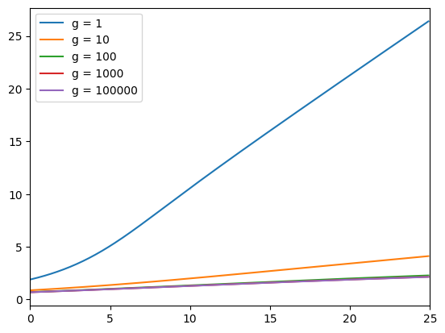

```python
for c in [1,10,100,1000,100000]:
    plt.plot(muval, LLnsolutions[str(c)],label=f'g = {c}' )
#plt.plot(freen,label='Free')
plt.legend()
plt.xlim(0,25)
```

```
(0.0, 25.0)
```

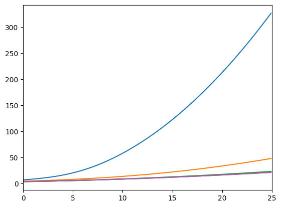

```python
for c in [1,10,100,1000,100000]:
    plt.plot(muval,LLesolutions[str(c)])
plt.xlim(0,25)
```

```python
#
gval = 10
idx = np.argmin(np.abs(np.array(LLnsolutions[str(gval)]) - 2.05))
print(LLnsolutions[str(gval)][idx],muval[idx],LLesolutions[str(gval)][idx]/LLnsolutions[str(gval)][idx])
```

```
2.0477784911737844 10.4 6.919061031172448
```